# Multiple Linear Regression

## Multiple Linear Regression Motivation

In most of our research studies, we have a lot of independent variables, rather than one single independent variable.

For example:

1. Emotions of news headline (valence & arousal) impact people's click-through-rate on news website.
2. Persuation strategies, such as fear appeal and rational appeal, impact the persuasion effectiveness.
3. The demographics (age, gender, race, income, etc.) impact people's political ideology.

We have learned that we can use simple linear regression to investigate the linear relationship between one independent variable with our dependent variable. But what we should do when we have a list of independent variables?

We use **Multiple Linear Regression**.

## Multiple Linear Regression Overview

In multiple linear regression, we have multiple independent variables, we can denote them as $X_1$, $X_2$ ..., $X_{p-1}$, and one dependent variable $Y$. Thus the model can be written as

$$ Y_i = \beta_0 + \beta_1 X_{i, 1} + \beta_2 X_{i, 2} + ... + \beta_{p-1} X_{i, p-1} + \epsilon_i $$

And the model assumes that

$$ E[\epsilon_i] = 0, \ \ \ \ \ \ \ \ \ Var(\epsilon_i) = \sigma^2, \ \ \ \ \ \ \ Cov(\epsilon_i, \epsilon_j)=0 $$

In this model, we have $p-1$ independent variables and $p$ regression coefficient $\beta_0, \beta_1, ..., \beta_{p-1}$

The estimated value for dependent variable using multiple regression model is

$$ \hat{Y_i} = \hat{\beta_0} + \hat{\beta_1} X_{i, 1} + \hat{\beta_2} X_{i, 2} + ... + \hat{\beta_{p-1}} X_{i, p-1} $$

## Multiple Linear Regression Overview

In a multiple linear regression model,

1. The effects of independent variables are **additive**.
2. The regression coefficient $\beta_k$ indicates for 1 unit change in independent variable $X_k$, how much unit should change in dependent variable $Y$, when other independent variables are held constant.
3. Simple linear regression can be considered as a **line**, multiple regression with two independent variables can be considered as a **plane**. Multiple regression with three or more independent variables can be considered as a **hyperplane**.

[figure not shown]

## Dummy coding for categorical independent variables

Multiple regression model requires independent variables and dependent variables to be quantitative values. But in statistical analysis, we commonly have categorical variables, such as gender, race, or genres.

To represent these categorical variables, we need to convert the categorical variable into quantitative variables.

One simple and commonly used approach is called **Dummy Coding**.

What this approach is basically to convert the multi-class categorical variables of $k$ classes, into $k$ columns of dummy variables of 0 and 1.

For instance, students class-standing can be categorized into 4 categories: undergraduate, graduate, professional, others. Then we can create 4 dummy coded variables to represent which class each sample fall into by 0 and 1.

As an example, a set of samples can be represented as

$$ \begin{bmatrix}undergraduate \\ graduate \\ graduate \\ professional \\ others \\ undergraduate \end{bmatrix} = \begin{bmatrix} 1 & 0 & 0 & 0 \\ 0 & 1 & 0 & 0 \\ 0 & 1 & 0 & 0 \\ 0 & 0 & 1 & 0 \\ 0 & 0 & 0 & 1 \\ 1 & 0 & 0 & 0 \end{bmatrix} $$

## OLS Method for Multiple Regression Model

Similar to simple linear regression model. We use OLS method to find the estimates of regression intercept $\hat{\beta_0}$ and regression coefficients for each of the independent variables $\hat{\beta_1}, \hat{\beta_2}, ..., \hat{\beta_{p-1}}$.

In OLS method, we are trying to minimize the sum of squared errors between the observed the data and the model-estimated value.

$$ Q = \sum (Y_i - \hat{Y_i})^2 = \sum (Y_i - \hat{\beta_0} - \hat{\beta_1} X_{i, 1} - \hat{\beta_2} X_{i, 2} - ... - \hat{\beta_{p-1}} X_{i, p-1})^2 $$

How do we solve this problem? We use the **matrix form** of multiple regression.

## Matrix form of Multiple Linear Regression Model

To express the multiple linear regression, similar to simple linear regression, we consider the dependent variable samples as our **response vector** $\boldsymbol{Y}$, and the samples of independent variables with intercept terms as our **design matrix** $\boldsymbol{X}$, and our regression coefficients as coefficients vector $\boldsymbol{\beta}$, and finally the error term for each of our sample to be a **error vector** $\boldsymbol{\epsilon}$.

The multiple regression model can be written as

$$ \begin{bmatrix} Y_1 \\ Y_2 \\ Y_3 \\ ... \\ Y_N \end{bmatrix} = \begin{bmatrix} \beta_0 * 1 + \beta_1 * X_{1, 1} + \beta_2 * X_{1, 2} + ... + \beta_{p-1} X_{1, p-1} \\ \beta_0 * 1 + \beta_1 * X_{2, 1} + \beta_2 * X_{2, 2} + ... + \beta_{p-1} X_{2, p-1} \\ \beta_0 * 1 + \beta_1 * X_{3, 1} + \beta_2 * X_{3, 2} + ... + \beta_{p-1} X_{3, p-1} \\ ... \\ \beta_0 * 1 + \beta_1 * X_{N, 1} + \beta_2 * X_{N, 2} + ... + \beta_{p-1} X_{N, p-1} \end{bmatrix} + \begin{bmatrix} \epsilon_1 \\ \epsilon_2 \\ \epsilon_3 \\ ... \\ \epsilon_N \end{bmatrix} $$

## Matrix form of multiple linear regression model

Eventually the model is denoted as

$$ \boldsymbol{Y}_{N \times 1} = \boldsymbol{X}_{N\times p}\boldsymbol{\beta}_{p \times 1} + \boldsymbol{\epsilon}_{N\times 1} $$

$$ \begin{bmatrix} Y_1 \\ Y_2 \\ Y_3 \\ ... \\ Y_N \end{bmatrix}_{N\times 1} = \begin{bmatrix} 1 & X_{1, 1} & X_{1, 2} & ... & X_{1, p-1} \\ 1 & X_{2, 1} & X_{2, 2} & ... & X_{2, p-1} \\ 1 & X_{3, 1} & X_{3, 2} & ... & X_{3, p-1} \\ ... & ... & ... & ... & ... \\ 1 & X_{N, 1} & X_{N, 2} & ... & X_{N, p-1} \end{bmatrix}_{N \times p} \begin{bmatrix} \beta_0 \\ \beta_1 \\ ... \\ \beta_{p-1} \end{bmatrix}_{p \times 1} + \begin{bmatrix} \epsilon_1 \\ \epsilon_2 \\ \epsilon_3 \\ ... \\ \epsilon_N \end{bmatrix}_{N \times 1} $$

## OSL in matrix form

Thus the sum of squared error $Q$ can be written as

$$ \begin{align} Q(\boldsymbol{b}) &= (\boldsymbol{Y} - \boldsymbol{X}\boldsymbol{b})^T(\boldsymbol{Y} - \boldsymbol{X}\boldsymbol{b}) \\ &= \boldsymbol{Y^T Y - b^TX^TY - Y^TXb +b^TX^TXb} \end{align} $$

The solution to this problem is the same as in simple linear regression

$$ \boldsymbol{\hat{\beta}} = \boldsymbol{b} = \boldsymbol{(X^TX)^{-1}X^TY} $$

And the variance-covariance matrix of regression coefficients estimate $\boldsymbol{\hat{\beta}}$ is

$$ \boldsymbol{\sigma^2\{\hat{\beta}\}} = \sigma^2 \boldsymbol{(X^TX)^{-1}} $$

## Expected value and variance of $\boldsymbol{\hat{\beta}}$

As we have shown previously, the expected value of regression coefficient estimates is

$$ \begin{align} \boldsymbol{E[b]} &= \boldsymbol{E[(X^TX)^{-1}X^TY]} \\ &= \boldsymbol{(X^TX)^{-1}X^TE[Y]} \\ &= \boldsymbol{(X^TX)^{-1}X^TX\beta} \\ &= \boldsymbol{I\beta} = \boldsymbol{\beta} \end{align} $$

Thus $\boldsymbol{\hat{\beta}}$ is an unbiased estimator of $\boldsymbol{\beta}$.

And the variance for each regression coefficient is the diagonal entries of the variance-covariance matrix .

$$ \sigma^2 \boldsymbol{(X^TX)^{-1}} $$

## Residuals and MSE

For multiple regression, after we have estimated the coefficients. We can obtain the residuals of the regression model

$$ \boldsymbol{e} = \boldsymbol{Y - X\beta} $$

The **sum of squared error** is $SSE = \sum e_i^2 =\boldsymbol{e^Te}$ with degree of freedom $d.f.(SSE) = N-p$. This is because we estimated a total of $p$ parameters - the regression coefficients.

And we can calculate the **mean squared error** as $MSE = \frac{SSE}{d.f.(SSE)} = \frac{SSE}{N-p}$, where $p$ is the number of independent variables $p-1$ plus the intercept term $N-(p-1)-1 = N-p$.

And we use this $MSE$ as our unbiased estimator of $\sigma^2$ for the error terms $\boldsymbol{\epsilon}$.

$$ \hat{\sigma^2} = MSE $$

## Multiple Regression T-test

With $MSE$ and the variance of each regression coefficient, we can calculate the standard error for each coefficient.

$$ s.e.(\hat{\beta_k}) = \sqrt{MSE * diagonal_k(\boldsymbol{(X^TX)^{-1}})} $$

And the $T$ statistics for the $k$th regression coefficient can be computed as

$$ T_{\hat{\beta_k}} = \frac{\hat{\beta_k}}{s.e.(\hat{\beta_k})} $$

The degree of freedom for the $T$ statistic is $N-p$, thus it follows a t distribution with $N-p$ degrees of freedom.

$$ H_0: \beta_k = 0 \ \ \ \ \ \ \ \ H_1: \beta_k \neq 0 $$ $$ T_{\hat{\beta_k}} \sim t_{N-p} $$

## Multiple Regression ANOVA

We can conduct $T$ test for each regression coefficient indivivdually for each regression coefficient.

We can also conduct a ANOVA test for the entire multiple regression model, including all regression coefficients.

By $F$ test, we have null hypothesis and alternative hypothesis for all regression coefficients:

$$ H_0: \beta_1 = \beta_2 = ... = \beta_{p-1} = 0 $$ $$ H_1: \text{Not all $\beta_k = 0$ for $k = 1, 2, ..., p-1$} $$

We can compute **Sum of Squares Total** $SSTO$, **Sum of Squared Error** $SSE$, and **Sum of Squares Regression** $SSR$.

$$ \begin{align} SSTO &= \sum (Y_i - \bar{Y})^2 \\ SSE &= \sum (Y_i - \hat{Y_i})^2 \\ SSR &= \sum (\hat{Y_i} - \bar{Y})^2 \\ SSTO &= SSE + SSR \end{align} $$

## Mean Squared Errors for multiple regression

As previously learned about $F$ test

$$ SSE \sim \sigma^2\chi^2_{N-p} $$

If $H_0: \beta_1 = \beta_2 = ... = \beta_{p-1} = 0$ holds, then we will have $SSR \sim \sigma^2\chi^2_{p-1}$.

The **degrees of freedom** for $SSE$ is $N-p$ and the **degrees of freedom** for $SSR$ is $p-1$.

We can compute the **Mean Squared Errors** $MSE$ and **Mean Squares Regression** $MSR$

$$ \begin{align} MSE &= \frac{SSE}{s.e.(SSE)} = \frac{SSE}{N-p} \\ E[MSE] &= \sigma^2 \\ MSR &= \frac{SSR}{s.e.(SSR)} = \frac{SSR}{p-1} \\ E[MSR] &= \sigma^2 \ \ \ \ \text{if $\beta_1 = \beta_2 = ... = \beta_{p-1}=0$} \end{align} $$

## F test for multiple regression

Thus, we can compute a $F$ statistic and conduct a $F$ test to test our hypothesis.

$$ F* = \frac{MSR}{MSE} \ \ \ \ \ \ \ F* \sim F_{p-1, N-p} $$

The $F$ statistic has two degree of freedom as $p-1$ which is the degree of freedom of $SSR$ and $N-p$ which is the degree of freedom of $SSE$.

We would reject the null hypothesis if $F* > F(1-\alpha; p-1, N-p)$

We can also build a ANOVA table

| Source of Variation | $SS$ | $d.f.$ | $MS$ | $F$ |
| --- | --- | --- | --- | --- |
| Regression | $SSR = \sum (\hat{Y_i}-\bar{Y})^2$ | $p-1$ | $MSR=\frac{SSR}{p-1}$ | $F*=\frac{MSR}{MSE}$ |
| Error | $SSE = \sum(Y_i-\hat{Y_i})^2$ | $n-p$ | $MSE=\frac{SSE}{n-p}$ |  |
| Total | $SSTO = \sum(Y_i - \bar{Y})^2$ | $n-1$ |  |  |

Note that: **F test is conducted for the entire model, while t test is conducted for a specific regression coefficient (independent variable).** Note that F test can be conducted for individual variables through ANOVA analysis.

## Coefficient of Determination

For multiple regression, we can decomposite the total variance in dependent variables into variance explained by the model, and the variance not explained as errors. Then, we can estimate the **percentage of variance explained by the model**, which is called **coefficient of detemination** or $R^2$.

We compute $R^2 = \frac{SSR}{SSTO} = 1- \frac{SSE}{SSTO}$

Something important about $R^2$ and multiple regression is that

1. $0 \le R^2 \le 1$ because $SSR \le SSTO$.
2. Adding more independent variables into the model will never decrease $R^2$, because more variables will not reduce the variance explained.

The question is when we are evaluating the goodness of a model using $R^2$, it will motivate us to add as much independent variables as possible, which could lead to **over-fitting** problem.

## Multiple Regression: Extra sum of squares

When we want to add new variables into an existing model with fewer independent variables, we want to know whether or not these added variables significantly improve the model or not.

In order to know whether or not a newly added variable or a set of newly added variables, we need to decomposite the sum of squares regression $SSR$.

Suppose we have three variables $X_1$, $X_2$, and $X_3$, we want to know whether or not $X_3$ can significantly improve the model.

We can decomposite $SSR_{X_1, X_2, X_3}$ into $SSR_{X_1, X_2}$ and $SSR_{X_3 | X_1, X_2}$, where $SSR_{X_3 | X_1, X_2}$ is the extra sum of squares explained by $X_3$ in addition to the existing two variables $X_1, X_2$.

$$ \begin{align} SSR_{X_1, X_2, X_3} &= SSR_{X_1, X_2} + SSR_{X_3 | X_1, X_2} \\ SSR_{X_1, X_2, X_3} &= SSTO - SSE_{X_1, X_2, X_3} \\ SSR_{X_1, X_2} &= SSTO - SSE_{X_1, X_2} \\ SSR_{X_3| X_1, X_2} &= SSR_{X_1, X_2, X_3} - SSR_{X_1, X_2} \\ &= SSTO - SSE_{X_1, X_2, X_3} - SSTO + SSE_{X_1, X_2} \\ &= SSE_{X_1, X_2} - SSE_{X_1, X_2, X_3} \end{align} $$

## Type II ANOVA test

For one targeted independent variable, we can compute its extra sum of squares in addition to the rest of the variables, for instance $SSR_{X_3| X_1, X_2}$, and compute its **Mean sum of squares** $MSR_{X_3|X_1, X_2} = \frac{SSR_{X_3|X_1, X_2}}{d.f.(SSR{X_3|X_1, X_2})}$, and compute its $F$ statistic.

$$ F* = \frac{MSR}{MSE} \sim F_{d.f.(SSR), d.f.(SSE)} $$

This type of test is called **type II** ANOVA test. It is a test of extra sum of squares explained by a independent variable in addition to the rest of the variables. And it is equivalent to $t$ test. In this case, the order of the variables entering the model does not matter.

## Hierarchical Regression

In some cases, we may care about the order of variables entering the model.

For instance, we want to explain the effect of valence and arousal of news headlines on click-through-rate of the news article. But we also have a set of variables that we do not care but will impact click-through-rate as well, such as length of the headline, read-easeness of the headline, etc. In these case, the headline length and reading easeness is called **control variable**.

When collecting human subject, we expect using basic demographic data (such as age, gender, race, etc) as control variables.

In order to test whether or not emotional features valence and arousal significantly improve the model, we can build two regression models

$$ \boldsymbol{M_1}: Click\_through\_rate \sim Headline\_length + Read\_easeness $$

$$ \boldsymbol{M_2}: Click\_through\_rate \sim Headline\_length + Read\_easeness + Valence + Arousal $$

## Hierarchical Regression

What we care about in this case is that whether or not $\boldsymbol{M_2}$ is significantly better than $\boldsymbol{M_1}$. In other words, whether or not the **Extra Sum of Squares** $ESS$ of $\boldsymbol{M_2}$ in addition to $\boldsymbol{M_1}$ is significantly or not.

So we can compute the

$$ \begin{align} SSR_{X_3, X_4 | X_1, X_2} &= SSR_{X_1, X_2, X_3, X_4} - SSR_{X_1, X_2} \\ &= SSE_{X_1, X_2} - SSE_{X_1, X_2, X_3, X_4} \\ MSR_{X_3, X_4 | X_1, X_2} &= \frac{SSR_{X_3, X_4 | X_1, X_2}}{d.f.(SSR_{X_3, X_4 | X_1, X_2})} \\ &= \frac{SSR_{X_3, X_4 | X_1, X_2}}{2} \\ F* &= \frac{MSR_{X_3, X_4 | X_1, X_2}}{MSE_{X_1, X_2, X_3, X_4}} \\ &= \frac{MSR_{X_3, X_4 | X_1, X_2}}{SSE_{X_1, X_2, X_3, X_4}/N-5} \sim F_{2, N-5} \end{align} $$

## Type I ANOVA Test

When we add each independent variable into the model one by one, and the order of the variable matters. We can use a Type I ANOVA model.

Different from Type II ANOVA test, which test for each variable as addition to all of the rest independent variable, Type I ANOVA test only test each variable in addition to previously added independent variable.

Type I test: $$ SSR_{A} \ \ SSR_{B|A} \ \ SSR_{C|B,A} \ \ SSR_{D|C,B,A},... $$

Type II test: $$ SSR_{A|B,C,D,...} \ \ SSR_{B|A,C,D,...} \ \ SSR_{C|A,B,D,...} \ \ SSR_{D|A,B,C,...},... $$

So, the order of variable added into the model matters for type I ANOVA test, but not for Type II ANOVA test.

## General Linear Test

A general form for ANOVA test for multiple regression model is to consider a **Full Model** with all variables $\boldsymbol{M_F}$, and a **Reduced Model** with all variables less some variable to be tested $\boldsymbol{M_R}$.

To test whether or not the reduced variables can significantly improve the regression model, we compute the sum of squares for the full model $SSR_F = SSTO - SSE_F$, the reduced model $SSR_R = SSTO-SSE_R$, and the sum of extra squares $SSR_{F|R} = SSR_F - SSR_R = SSE_R - SSE_F$

Then, we construct and compute the mean squared errors for the full model $MSE_F = \frac{SSE_F}{d.f.(F)}$, and the mean squares of extra sum of squares for the variables being reduced $MSR_{F|R} = \frac{SSR_{F|R}}{d.f.(F)-d.f.(R)}$, where the degree of freedom is the number of variables being reduced.

And finally, we compute the $F$ statistic

$$ F* = \frac{MSR_{F|R}}{MSE_F} \sim F_{d.f.(R)-d.f.(F), d.f.(F)} $$

We can use this test to compare for any the **Nested** models.

## Nested Models

Nested models are a list of models whose set of parameters is incremental.

For instance, nested models can be the following:

$$ \boldsymbol{M_1}: Click\_through\_rate \sim Headline\_length + Read\_easeness $$

$$ \boldsymbol{M_2}: Click\_through\_rate \sim Headline\_length + Read\_easeness + Valence $$

$$ \boldsymbol{M_3}: Click\_through\_rate \sim Headline\_length + Read\_easeness + Valence + Arousal $$

Thus, with the General Linear Test, we can use the $F$ test to test significance for a set of variables or a single variable in addition to a set of existing variables.

## Partial Coefficients

When we fit a multiple regression, we obtain an estimate for each of the regressors (independent variable) $\hat{\beta_k}$.

How should we interpret this regression coefficient?

We know that for simple linear regression, it is straightforward $\beta_1 = \frac{r_{x,y}s_y}{s_x}$, it is the unit change in $X$ lead to the unit change in $Y$.

For multiple regression, it is a bit complex, because this coefficient is actually a **partial coefficient**, that only accounts to the part of change $Y$ after accounting for the rest of the independent variables.

This partial coefficient $\hat{\beta_k}$ equals the simple linear coefficient of two types of residuals without intercept, the residuals of dependent variable $Y$ regressed on all other independend variables except variable $X_k$, and the residuals of variable $X_k$ regressed on all other independent variables except $X_k$.

$$ Y \sim 1+ X_1 + X_2 + ... X_{p-1}\text{without $X_k$} \ \ \ \ \ \ \ e(Y|-k) = Y - \hat{Y}(-k) $$ $$ X_k \sim 1+ X_1 + X_2 + ... X_{p-1}\text{without $X_k$} \ \ \ \ \ \ \ e(X_k|-k) = X_k - \hat{X_k}(-k) $$ $$ e(Y|-k) \sim e(X_k|-k) $$

## Interpretation of Partial Coefficients

The partial coefficient $\hat{\beta_k}$ is the regression coefficient of $e(Y|-k)$ regressed on $e(X|-k)$ without intercept term.

It can be interpreted such that the multiple regression coefficient for a variable $X_k$ are coefficient after accounting for the relationship between dependent variable and all other variables except $X_k$, and the relationship between $X_k$ and the rest of the independent variables.

It is the coefficient that is **Exclusive** for the linear relationship between $Y$ and $X_k$, after removing the effects of all other independent variables.

## Partial Coefficients of Determination

For simple linear regression, we can compute a coefficient of determination that is $R^2 = \frac{SSR}{SSTO}$, which is the percentage of variance explained by the single independent variable.

For multiple regression, we can also compute a coefficient of determination that is the percentage of variance explained by all of the independent variables.

What if we want to compute the percentage of variance that is exclusively explained by a single independent variable after excluding the effect of all other variables?

This is called **Partial Coefficient of Determination**

Following the same idea that $R^2 = \frac{SSR}{SSTO}$, we need to compute the $SSR$ for the variable $X_k$ after accounting for the rest of the variables, and the $SSTO$ after accounting for the rest of the variables except $X_k$.

$Partial\ R^2(X_k) = \frac{SSR_{X_k | X_1, X_2, ..., X_{k-1}, X_{k+1}, ..., X_{p-1}}}{SSE_{X_1, X_2, ..., X_{k-1}, X_{k+1}, ..., X_{p-1}}}$

## Partial Coefficients of Determination Example

If we have three variables $X_1, X_2, X_3$ in a multiple regression, and we want to compute the partial coefficient of determination of $X_3$.

We first compute the extra sum of squares of $X_3$ after accounting for $X_1, X_2$.

$$ SSR_{X_3|X_1, X_2} = SSE_{X_1, X_2} - SSE_{X_1, X_2, X_3} $$

$$ Partial R^2(X_3) = \frac{SSR_{X_3|X_1, X_2}}{SSE_{X_1, X_2}} = \frac{SSE_{X_1, X_2} - SSE_{X_1, X_2, X_3}}{SSE_{X_1, X_2}} = 1-\frac{SSE_{X_1, X_2, X_3}}{SSE_{X_1, X_2}} $$

## Partial Coefficients of Determination Interpretation

Similar to simple linear regression that the coefficient of determination equals to the squared correlation efficient between $X$ and $Y$.

$$ R^2 = r(X,Y)^2 $$

We can interpret the partial coefficient of determination as the squared partial correlation between the residuals of $Y$ after accounting for the rest of the independent variables, and the residuals of $X_k$ after accounting for the rest of the independent variables.

$$ Partial R^2(X_k) = r(e(Y|-k), e(X_k|-k))^2 $$

## Correlation between independent variables

We now know that our multiple regression model estimates coefficients by considering how much the specific independent variable has effect on the dependent variables after accounted for the rest of the independent variables ($e(Y|-k)$), and the correlation between the specific independent variable with the rest of independent variables ($e(X_k, -k)$).

Thus, when our independent variables are intercorrelated:

1. The regression coefficient of an $X$ variable will depend on other $X$ variables in the model.
2. Regression coefficient does not reflect any inherent relationship between the specific $X$ variable with dependent variable $Y$, but only marginal effect given exisiting indepdent variables already in the model.
3. The reduction of total errors in the dependent variable $Y$ being attributed to a specific independent variable $X$ must be interpreted as a margin reduction of errors given other independent variables in the model.

## Multicollinearity

Thus, when our of interest independent variable is highly correlated with other independent variables or can be explained by other independent variables, it can cause severe problems for estimating its coefficient and conducting statistical inference. This problem is called **Multicollinearity**.

Multicollinearity occurs when your independent variables are intercorrelated. It can cause:

1. Dramatic change in the regression coefficient estimate
2. Very high standard error for the regression coefficient estimate
3. Non-significant t-test for the regression coefficients, but significant model F test

# Multiple Regression Diagnostics

Similar to simple linear regression, multiple regression relies on a set of assumptions:

1. Linearity between fitted value and residuals
2. Independence of residuals
3. Constant variance of residuals
4. Normality of residuals
5. No extreme outlying data
6. **Multicolinearity**

We will go through them one by one.

## Linearity assumption

To check the linearity between independent variables and dependent variables.

We need to use the residual vs. fitted value plot.

## Linearity assumption

[figure not shown]

## Treatment for linearity

Violation of linearity can be severe for our multiple regression model.

To treat this violation, we need to account for the non-linearity in the residuals.

Two basic approaches can be used:

1. Polynomial regression model
2. Multiple regression with interactions

## Polynomial regression model

By using polynomial regression, we are creating new independent variables by adding existing variable of higher orders.

For instance, if there is a non-linear relationship between $X_1$ and $Y$ shown below

$$ Y \sim X_1 $$

[figure not shown]

## Polynomial regression model

For a U-shaped non-linear relationship, we can create the second-order variable of $X_1$ as $X_1^2$ and add this new variable into the existing regression model.

$$ Y_i = \beta_0 + \beta_1 X_1 + \beta_2 X_1^2 + \epsilon_i $$

Variables of higher order will usually address the non-linear relationship between the dependent variable and a specific independent variable.

When the non-linear relationship between $X_1$ and $Y$ is more complex than a U-shape curve, then you might consider to add even higher order variables, such as $X_1^3$ or $X_1^4$

[figure not shown]

```python
from scipy.stats import norm
import numpy as np
from statsmodels.tools.tools import add_constant
from matplotlib import pyplot as plt
```

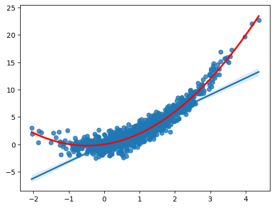

```python
x = norm.rvs(size=1000) + 1
e = norm.rvs(size=1000, loc=0, scale=1)
y = x+x**2+e
sns.regplot(x=x, y=y)
sns.regplot(x=x, y=y, order=2, color="red", scatter=False)
```

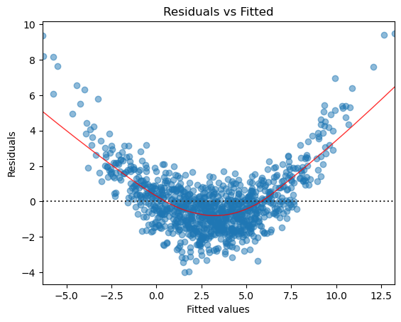

```python
X_1 = np.array([x]).T
X_1 = add_constant(X_1)
model = sm.OLS(exog=X_1, endog=y).fit()
sns.residplot(x=model.fittedvalues, y=model.resid,
                          lowess=True,
                          scatter_kws={'alpha': 0.5},
                          line_kws={'color': 'red', 'lw': 1, 'alpha': 0.8})
plt.title('Residuals vs Fitted')
plt.xlabel('Fitted values')
plt.ylabel('Residuals');
```

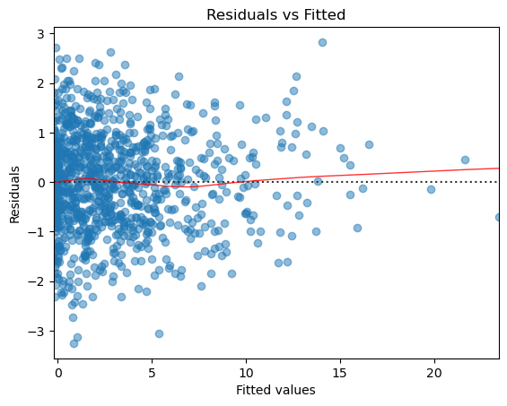

```python
X_2 = np.array([x, x**2]).T
X_2 = add_constant(X_2)
model_second_order = sm.OLS(exog=X_2, endog=y).fit()
sns.residplot(x=model_second_order.fittedvalues, y=model_second_order.resid,
                          lowess=True,
                          scatter_kws={'alpha': 0.5},
                          line_kws={'color': 'red', 'lw': 1, 'alpha': 0.8})
plt.title('Residuals vs Fitted')
plt.xlabel('Fitted values')
plt.ylabel('Residuals');
```

## Multiple regression with interaction

When the non-linear relationship between independent variables and dependent variables involves a non-additive relationship.

For instance, You are studying how message exposure and message relevance influence persuasion in a public health campaign. The dependent variable (DV) is attitude toward the health behavior (e.g., adopting regular exercise).

Both message exposure and message relevance influence people's attitudes, but they also interact with each other when influencing attitude. That is, there might be a positive interaction between message exposure and message relevance, meaning when message relevance is high, higher message exposure leads to higher attitude (DV). However, when message relevance is low, higher message exposure does not lead to higher attitude (DV).

When you fit a regression model without interaction, your model does not accurately capture the actual relationship between your independent variables and your dependent variable, thus could lead to a non-linearity in your model.

$$ Attitude \sim Exposure + Relevance $$

Thus, to accurately capture this non-linearity, you need to add an additional term $Exposure * Relevance$ into your model.

$$ Attitude \sim Exposure + Relevance + Exposure * Relevance $$

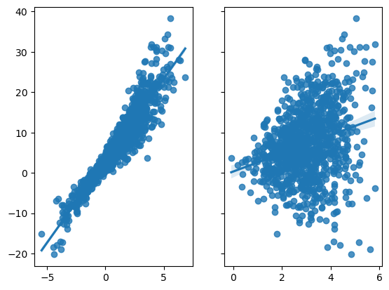

```python
x = norm.rvs(size=1000, loc=1, scale=2)
y = norm.rvs(size=1000, loc=3, scale=1)
e = norm.rvs(size=1000, loc=0, scale=1)
z = x+y+x*y+e

fig, ax = plt.subplots(1, 2, sharey='row')
sns.regplot(x=x, y=z, ax=ax[0])
sns.regplot(x=y, y=z, ax=ax[1])
```

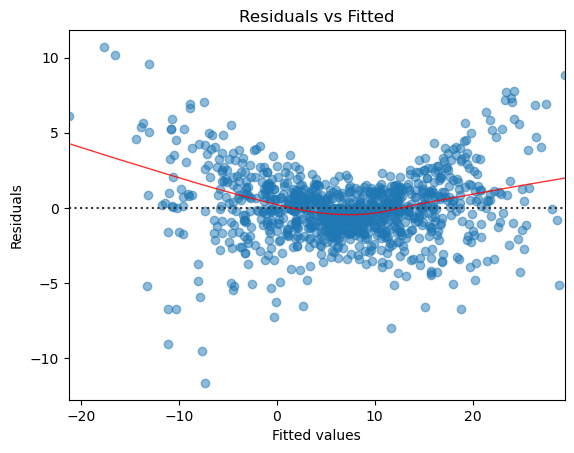

```python
X_1 = np.array([x,y]).T
X_1 = add_constant(X_1)
model = sm.OLS(exog=X_1, endog=z).fit()
sns.residplot(x=model.fittedvalues, y=model.resid,
                          lowess=True,
                          scatter_kws={'alpha': 0.5},
                          line_kws={'color': 'red', 'lw': 1, 'alpha': 0.8})
plt.title('Residuals vs Fitted')
plt.xlabel('Fitted values')
plt.ylabel('Residuals');
```

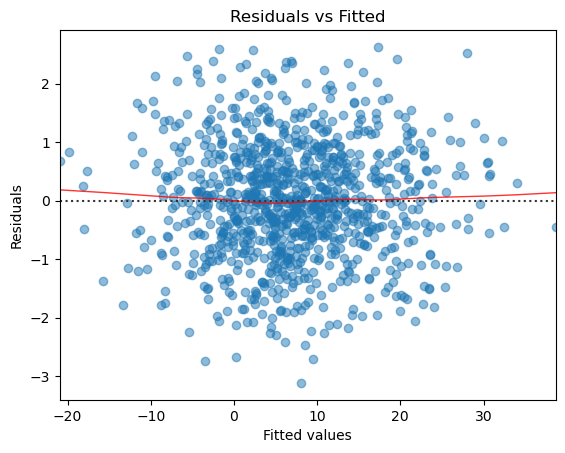

```python
X_1 = np.array([x,y,x*y]).T
X_1 = add_constant(X_1)
model = sm.OLS(exog=X_1, endog=z).fit()
sns.residplot(x=model.fittedvalues, y=model.resid,
                          lowess=True,
                          scatter_kws={'alpha': 0.5},
                          line_kws={'color': 'red', 'lw': 1, 'alpha': 0.8})
plt.title('Residuals vs Fitted')
plt.xlabel('Fitted values')
plt.ylabel('Residuals');
```

## Normality assumption of errors

Likewise, we assumed that the error term follow a normal distribution. And we have shown that this can be deteced by a Q-Q plot of model residuals.

[figure not shown]

## Treatment of voilation of normality assumption

The voilation of normality assumption most likely occures when our variables does not follow a normal distribution.

For instance, the popularity of songs, or how much money people have will be a highly right-skewed variable.

In these cases, we can treat this problem by **transformation** of our dependent variables.

Common transformation includes **log transformation** or **Box-Cox transformation**. We have covered box-cox transformation in our previous assignment, so we will skip it here.

Another common approach or probably more appropriate approach is to use **General Linear Model(GLM)**, which does not assume normality of errors at all. We will cover **GLM** in our next lecture.

## Constant Error Assumption

Constant Error Assumption assumes that our residuals have constant variance across our independent variables.

This can be detected using the fitted vs. residual plot as well.

[figure not shown]

## Treatment of Non constant errors (heteroscedasticity)

The reason for why non-constant errors occur can have many potential causes.

Sometimes, we can treat it by simply transforming variables by a simple log transformation or more advanced method such as Box-Cox transformation or GLM.

In some other times, it occurs because our model missed important variables or factors. So, we might treat it by adding more terms into the regression model, such as interaction between variables.

In other times, we might need to apply a **Weighted Least Square** approach, which weight each sample in our dataset by their corresponding error variance.

## Independence Assumption of errors

For multiple regression, we assumes that error samples are independent to each other, and there is no correlation between our residuals.

The voilation of independence assumption occurs when we have neglected important dependency relationship among our collected samples.

For instance, we have collected students' grades from three classrooms, and test the relationship between the time spent on study and their final grades.

In this case, the three groups of samples are not independent with each other, thus violated the independence assumption.

Or we have ignored important sequential relationship among time series data. For example, the stock price at this moment will depend on its previous moment, which called autocorrelation.

The violation of independence assumption depends on the type of data you collected. And a general method to detect it is by residual plots, such as **residual vs. fitted value** plot, **residual vs. order (order of data collection)** plot, or **residual vs. other residuals** (for autocorrelation) plot.

## Treatment of independence assumption

Treatment of independence assumption depends on the causes.

Sometimes, we can treat it by adding neglected factors into the regression model by recovering the independence of the errors.

For example, for time series data that is autocorrelated, we can add the dependent variable at the previous time as a independent variable

$$ Y_t \sim Y_{t-1} + X_1 + X_2 + ... $$

When it is caused by our sample is structured into multiple groups. We will need to add the group categorical variable (dummy coded) into our model, or use mixed effect model to recover the indepdence of residuals. We will cover mixed effect model in our next class.

## Outlying data

Outlying data can have dramatic influence on our estimated model.

As introduced earlier, this can be detected computing **levarage** and **cook's distance** for our data samples.

We can plot the **leverage vs. residual** plot

[figure not shown]

## Treatment of outlying data

When we have outlying data, its treatment is usually pretty straightforward.

When we have a lot of outliers, it is usually because our variables are heavily skewed data, which will demand a data transformation.

When we have a few outliers, we can remove these outliers depending on our data exclusion criterion. It will be extremely helpful to specify a data exclusion critirion before the data collection.

## Multicollinearlity

As explained earlier, multicollinearity can cause issues for us when conducting our significance testing on regression coefficients.

We can detect multicollinearity by computing the **variance inflation factor (VIF)**. The $VIF$ for variable $X_k$ is computed by regressing the variable $X_k$ on the rest of the independent variables. If $X_k$ can be explained by other random variables to a great extent, that would indicates the random variable $X_k$ has a multicollinearity issue.

$$ VIF_k = \frac{1}{1-R_k^2} $$

where $R_k^2$ is the coefficient of determination of regression $X_k$ on the rest of the independent variables.

Usually, we consider a variable to have high multicollinearity when $VIF_k > 5$. When diagnosing for a model, we can evaluate the average of $VIF$ or the maximum of $VIF$ to determine if multicollinearity causes problems for the model.

## Treatment of multicollinearity

To treat a multicollinearity issue, we can consider removing this independent variable from our regression model.

When two or multiple independent variables are highly intercorrelated, depending on their theoretical context, we may consider computing an average to represent them.

In some other cases, we can consider a dimension reduction approach to address multicollinearity issue by using approaches such as **Priciple Component Analysis (PCA)**, which will reduce the number of variables we have and generating uncorrelated variables which is called **principle components**.

## Model Error and Evaluation

What makes a model a good model? How do we evaluate the goodness of a model?

One potential evaluation criterion is to evaluate how much variance it can explain for our dependent variable by reducing the $SSE$.

However, the critical problem of this evaluation is that it only evaluates the capacity of the model to **explain** the existing data because the $SSE$ is computed for existing data, which is a random sample of the population.

When evaluating the goodness of a model, we need to evaluate how good this model is for the entire population, not just for our collected samples.

One simple approach is to evaluate by **prediction**, which is to evaluate the errors of the model for the out-of-sample data (data that is not used for fitting the regression model).

## Prediction/Model Error

As we have introduced when learning simple linear regression. The prediction error interval is larger than the confidence interval, because it accounts for both the model bias and model variance.

We can evaluate the model error as the sum of squared errors between the estimated value and the true population mean for our samples, which is called **Mean-Squared-Estiamtion-Error** $MSEE$

Model error is Model variance plus Model bias.

Model bias is the errors that can not explained by our model, which is the true $\sigma^2$.

Model variance is the variance of our model parameters, which is caused by the difference between our samples and the population.

Consider if we conduct a study and fit a regression model 10 times with different samples. Are we going to get the exact the same model coefficients?

As we add more and more variables into our model and making it more and more complex, our model errors will decrease, because adding more variables will decrease $SSE$, but our model variance will increase because we have introduced new parameters to be estimated, this is called **bias-variance trade-off**.

## Bias-Variance Trade Off

[figure not shown]

## Model Evaluation by considering bias and variance

When we are evaluating the goodness of our model, we need to reduce both model bias and model variance by finding an optimal level of model complexity.

When we add too many variables to our model and improve its accuracy, it can introduce high model variance, which will harm its prediction accuracy. This is called **Over-Fitting**. It means the model is only good for our collected sample and does not work for data out-of-sample, aka the entire population.

A **Good Model** does not necessarily equal a **Correct** model.

An correct model means a model that is accurate by minimizing the errors. A good model means controlling for model errors and model variance.

The next question is, how do we measure the goodness of the model?

## Model Evaluation Metrics

There are a lot of model evaluation metrics.

The simplest metric is $R^2$, and as we have discussed, it will only reward for reducing model errors and does not care about model variance, which will motivate us to introduce as many variables as possible. It is recommended to not use $R^2$ in any cases to evaluate the goodness of the model.

$$ R^2 = \frac{SSR}{SSTO} = 1-\frac{SSE}{SSTO} $$

An improved metric from $R^2$ is $Adjusted\ R^2$, which is different from $R^2$ because it will punish the model if the model includes too many parameters.

$$ Adjusted \ \ R^2 = 1-\frac{MSE}{MSTO} = 1-\frac{N-1}{N-p}\frac{SSE}{SSTO} $$

When $p$ increases, $\frac{N-1}{N-p}$ also increases, thus $Adjusted \ \ R^2$ decreasese.

## Mallow's $C_p$

Another metric is called Mallow's $C_p$, which is calculated as

$$ C_p = \frac{SSE_p}{\hat{\sigma^2}} - (N-2p) $$

Steps to compute $C_p$ for a model with $p-1$ variables.

1. Fit the model with all possible independent variables, and estimate its $MSE$ as $\hat{\sigma^2}$
2. For a model to be evaluated, fit this model, and compute its $SSE$ as $SSE_p$.
3. Compute the $C_p = \frac{SSE_p}{\hat{\sigma^2}} - (N-2p)$

Steps to consider the best model.

1. Plot $C_p$ against the number of variables $p$.
2. Looking for models with $C_p$ close to the diagonal line $C_p=p$, which indicates little bias.
3. For models close to the diagonal line, look for models with the smallest $p$, which indicates little variance.

## Mallow's $C_p$

[figure not shown]

## Other evaluation metrics

We also have other evaluation metrics such as **Akaike’s information criterion** $AIC$ and **Bayesian information criterion** $BIC$.

$$ AIC_p = Nlog\frac{SSE_p}{N} + 2p $$

$$ BIC_p = Nlog\frac{SSE_p}{N} + log(N)p $$

We look for models with the smallest $AIC_p$ or $BIC_p$.

## $Press_p$ evaluation Leave-One-Out Prediction

The Predicted residual sum of squares $Press_p$ is calculated as

$$ Press_p = \sum_i^N (Y_i-\hat{Y_{i, (i)}})^2 $$

This metrics is also called **Leave-One-Out Cross-validation** (LOOCV), which is

1. fit the regression model after removing one sample from the dataset.
2. Estimate the squared errors of predicting this removed sample with the model that was fitted outout this sample.
3. Repeat this process for all of the samples, and take a sum of these Leave-One-Out prediction squared errors.

$Press_p$ is a method to evaluate prediction errors with existing data and not collecting extra data for estimate prediction errors.

We look for models with the lowest $Press_p$

## Prediction Accuracy

Another method is to actually evaluate the prediction accuracy of the model for out-of-sample data, which is mostly commonly used in data science and machine learning.

1. We split the dataset into two subset of dataset, one for training, and one for testing
2. We estimate our model using the training dataset
3. We evaluate our model using the testing dataset by calcualting the sum of squared errors for its prediction.

# Multiple Regression Model Selection

When we are building a multiple regression model, we can potentially have infinite number of independent variables, by collecting more data, creating higher order variables, or creating interaction terms.

Likewise, when evaluating which model is the best, we can potentially have a very large number of candidate models to be evaluated.

For instance, for 4 independent variables, even without creating higher-order or interaction terms.

We can potentially have ${4\choose 1} + {4\choose 2} + {4\choose 3} + {4\choose 4} = 4 + 6 + 4 + 1 = 15$ candicate models.

When we have more independent variables, this number will increase exponentially.

So, we need a strategy to find the best model more efficiently.

## Model Selection

This problem is called **model selection**, that is to find the optimal subset of independent variables in regression that has the best performance.

There are multiple ways to conduct a model selection.

The first method is the easiest. We simply estimate for all potential models, evaluate them by our evaluation metrics, and find the optimal model.

Other methods commonly used is called **Step-wise regression procedures**

## Step-wise Regression

Step-wise Regression Use “greedy” search strategies to examine a sequence of models by adding or deleting only one X variable according to a pre-specified criterion (e.g., AIC) at each search step.

It could end up with a local optimal model rather than the global “best” model.

## Forward stepwise

The forward stepwise regression procedure follows the following steps

1. determine a set of independent variables $X$
2. determine a evlauation metrix, such as $AIC$
3. determine an intial model $M_0$, such as the model with only intercept
4. Start with the current model, and from the pool of independent variables that is not in the current model, find a variable that improves the metric the best.
5. From the current model, find a variable that improve the model the best after dropping this variable.
6. Either add the variable not in the model, or drop the variable in the model by which way improves the metric the best.
7. Repeat this process until it can not improve the model anymore.

## Forward Selection and Backward Elimination

**Forward selection** is a simplified version of forward stepwise procedure by omitting the considerations of dropping a variable currently in the model at each step.

**Backward elimination** is the opposite of the forward selection:

1. Start with a “big” initial model, e.g., the full model.
2. At each step, examine the change of the criterion by dropping a variable currently in the model.

## Stepwise Procedures: Comparisons

Forward stepwise procedure often works better than forward selection when there is high multicollinearity among the potential X variables.

Backward procedures are not good when the number of potential X variables is large. Particularly, they are not feasible when P > n, since then the full model can not be fitted.

## Model Validation

After we have found the optimal model using model selection procedure, we can validate our found model by evaluating its prediction accuracy.

We can do internal validation using metrics $C_p$ or $Press_p$, which does not require collecting additional data, or spliting the data into training and testing dataset.

We can also do external validation by measuring the **Mean Squared Prediction Error** by averaging the sum of squared errors of predicted values.